# Simulation: generating synthetic retrieval-practice data

Thomas Wilschut Last updated: 2026-10-01

- Setup
- Simulate data
- Checks
  - Parameter distributions and their relationship to behavior (Figure 2)
  - Effect of parameters on RT after accounting for non-retrieval time (Reviewer 2, comment 3; supplementary)
  - Check 2: Observed accuracy vs. predicted P(correct)
  - Check 3: Learning curves — accuracy and RT over repetitions
  - Check 4: Effect of fact-level offsets (Δα) on accuracy and RT
  - Check 5: Correct vs. incorrect RT distributions
- Session info

This markdown file is can be used to reproduce the results reported in the paper: Idiographic Memory Modelling in ACT-R using Alternating Maximum Likelihood Estimation

This script is used to simulate the data, corresponding to the section: Simulation: Recovering parameters from synthetic data.

# Setup

```r
library(here)
library(data.table)
library(janitor)
library(ggplot2)
library(purrr)
library(furrr)
library(progressr)
library(tidyr)
library(jsonlite)
library(patchwork)
library(ggExtra)
library(lmerTest)
library(dplyr)
library(ggsci)

# Set up parallel processing
plan(multisession, workers = availableCores() - 1)

# Load the simulation, fitting, and recovery functions:
source(here::here("R", "sim-mle.R"))

# Define colours
col_blue <- "#0571b0"
col_red <- "#ca0020"
col_green <- "#1b9e77"
```

# Simulate data

Let’s first simulate data for 50 learners, each learning 15 facts, with 10 repetitions per fact. We set a seed for reproducibility. For more details on the simulation procedure, see the `sim_mle.R` script.

Each learner is assigned a set of person-level parameters (drawn from the truncated normal distributions in `sim-mle.R`), and each fact within a learner gets a fact-level Speed of Forgetting offset (Δφ). The simulator then generates a study trial plus repeated retrieval trials per fact, recording response accuracy and response time for every trial. The first encounter of each fact is flagged with `is_study == TRUE` and is excluded from likelihood evaluation later on.

```r
sim <- simulate_fact_learner_data(
  n_learners    = 50,
  n_facts       = 15,
  n_repetitions = 10,
  seed          = 999
)
```

[output not shown]

# Checks

Next, we will inspect to see if the simulated data fits our expectations.

## Parameter distributions and their relationship to behavior (Figure 2)

This reproduces Figure 2 of the paper. Panel A shows the sampled distribution of each of the five person-level parameters across the 50 learners; panels B and C relate each parameter to aggregate accuracy and median RT, so we can verify that the simulator induces the expected behavioural signatures before fitting anything.

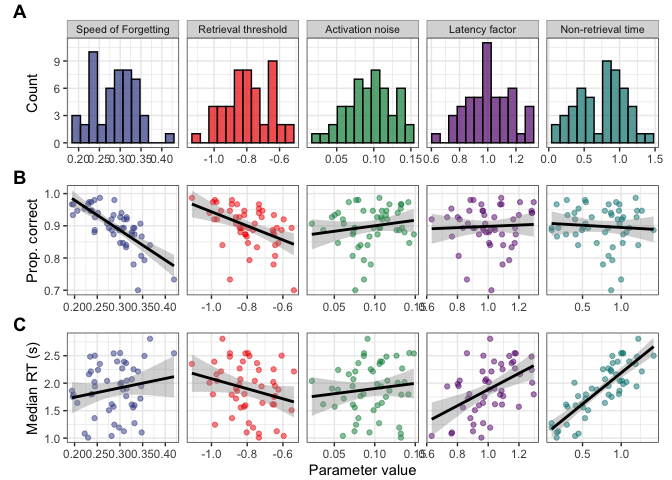

```r
# ── Shared factor levels (controls column order) ──────────────────────────────
param_levels <- c(
  "Speed of Forgetting",
  "Retrieval threshold",
  "Activation noise",
  "Latency factor",
  "Non-retrieval time"
)

# ── A: Parameter distributions ────────────────────────────────────────────────
sim_test <- sim[is_study == FALSE]

param_long <- sim_test %>%
  distinct(user_id, true_phi, true_tau, true_s, true_lf, true_ter) %>%
  pivot_longer(
    cols      = c(true_phi, true_tau, true_s, true_lf, true_ter),
    names_to  = "parameter",
    values_to = "value"
  ) %>%
  mutate(
    parameter = recode(parameter,
      "true_phi" = "Speed of Forgetting",
      "true_tau"   = "Retrieval threshold",
      "true_s"     = "Activation noise",
      "true_lf"    = "Latency factor",
      "true_ter"   = "Non-retrieval time"
    ),
    parameter = factor(parameter, levels = param_levels)
  )

# ── B & C: Parameters vs behavioural outcomes (per learner) ───────────────────
learner_summary <- sim_test %>%
  group_by(user_id, true_phi, true_tau, true_s, true_lf, true_ter) %>%
  summarise(
    accuracy = mean(correct),
    med_rt   = median(rt),
    .groups  = "drop"
  ) %>%
  pivot_longer(
    cols      = c(true_phi, true_tau, true_s, true_lf, true_ter),
    names_to  = "parameter",
    values_to = "param_value"
  ) %>%
  mutate(
    parameter = recode(parameter,
      "true_phi" = "Speed of Forgetting",
      "true_tau"   = "Retrieval threshold",
      "true_s"     = "Activation noise",
      "true_lf"    = "Latency factor",
      "true_ter"   = "Non-retrieval time"
    ),
    parameter = factor(parameter, levels = param_levels)
  )

# ── Shared x-range per parameter (aligns all three rows) ─────────────────────
param_ranges <- learner_summary %>%
  group_by(parameter) %>%
  summarise(xmin = min(param_value), xmax = max(param_value), .groups = "drop") %>%
  pivot_longer(c(xmin, xmax), names_to = "bound", values_to = "value") %>%
  select(parameter, value) %>%
  mutate(parameter = factor(parameter, levels = param_levels))

# ── Plot A: distributions ─────────────────────────────────────────────────────
distr <- ggplot(param_long, aes(x = value, fill = parameter)) +
  geom_histogram(bins = 12, color = "black", alpha = 0.7) +
  geom_blank(data = param_ranges, aes(x = value), inherit.aes = FALSE) +
  facet_wrap(~ parameter, scales = "free_x", ncol = 5) +
  labs(x = NULL, y = "Count") +
  theme_bw() +
  theme(
    legend.position  = "none",
    strip.background = element_rect(fill = "grey85", colour = "grey60"),
    strip.text       = element_text(size = 8, margin = margin(3, 3, 3, 3)),
    plot.margin      = margin(10, 20, 10, 20)
  ) +
  scale_x_continuous(
    breaks = scales::pretty_breaks(n = 4)
  ) +
  scale_fill_aaas()

# ── Plot B: accuracy ──────────────────────────────────────────────────────────
acc <- ggplot(learner_summary, aes(x = param_value, y = accuracy, color = parameter)) +
  geom_point(alpha = 0.5) +
  geom_smooth(method = "lm", color = "black", se = TRUE) +
  geom_blank(data = param_ranges, aes(x = value), inherit.aes = FALSE) +
  facet_wrap(~ parameter, scales = "free_x", ncol = 5) +
  labs(x = NULL, y = "Prop. correct") +
  theme_bw() +
  theme(
    legend.position  = "none",
    strip.background = element_blank(),
    strip.text       = element_blank(),
    plot.margin      = margin(10, 20, 10, 20)
  ) +
  scale_x_continuous(
    breaks = scales::pretty_breaks(n = 4)
  ) +
  scale_color_aaas()

# ── Plot C: response time ─────────────────────────────────────────────────────
rt_plot <- ggplot(learner_summary, aes(x = param_value, y = med_rt, color = parameter)) +
  geom_point(alpha = 0.5) +
  geom_smooth(method = "lm", color = "black", se = TRUE) +
  geom_blank(data = param_ranges, aes(x = value), inherit.aes = FALSE) +
  facet_wrap(~ parameter, scales = "free_x", ncol = 5) +
  labs(x = "Parameter value", y = "Median RT (s)") +
  theme_bw() +
  theme(
    legend.position  = "none",
    strip.background = element_blank(),
    strip.text       = element_blank(),
    plot.margin      = margin(10, 20, 10, 20)
  ) +
  scale_x_continuous(
    breaks = scales::pretty_breaks(n = 4)
  ) +
  scale_color_aaas()

# ── Combine ───────────────────────────────────────────────────────────────────
distr / acc / rt_plot +
  plot_annotation(tag_levels = "A") &
  theme(
    plot.tag      = element_text(face = "bold", size = 14),
    plot.margin   = margin(1, 5, 1, 5),
    panel.spacing = unit(0.4, "lines")
  )
```

```r
# Paper Figure 2: parameter distributions and their relation to behaviour
ggsave(here::here("output", "parameter_distributions_and_behaviour.png"), width = 10, height = 6.5)
```

Panel A shows the distributions of the five simulated person-level parameters. Panels B and C show how each parameter relates to aggregate accuracy and median RT, respectively. Speed of forgetting (φ) and retrieval threshold (τ) should show the clearest relationships with accuracy; latency factor (F) and non-retrieval time (t<sub>er</sub>) should primarily affect RT.

## Effect of parameters on RT after accounting for non-retrieval time (Reviewer 2, comment 3; supplementary)

In Figure 2 (panel C), median RT scales approximately linearly with non-retrieval time (t<sub>er</sub>), since t<sub>er</sub> is added directly on top of the retrieval-related component of RT. To check that the (weaker) relationships visible for the other parameters in panel C are not simply an artefact of this additive offset, we recompute median RT after subtracting each learner’s own t<sub>er</sub> from every trial (i.e. their median “decision time”, RT − t<sub>er</sub>), and relate this to φ, τ, s, and F. t<sub>er</sub> itself is excluded here, since subtracting t<sub>er</sub> from RT trivially removes its own effect.

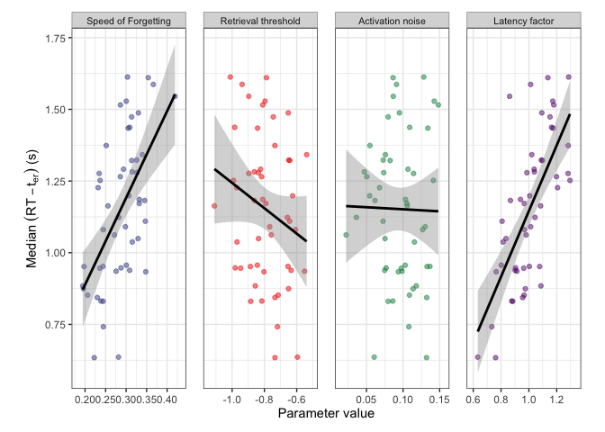

```r
sim_test[, decision_time := rt - true_ter]

learner_summary_ex_ter <- sim_test %>%
  group_by(user_id, true_phi, true_tau, true_s, true_lf) %>%
  summarise(
    med_decision_time = median(decision_time),
    .groups = "drop"
  ) %>%
  pivot_longer(
    cols      = c(true_phi, true_tau, true_s, true_lf),
    names_to  = "parameter",
    values_to = "param_value"
  ) %>%
  mutate(
    parameter = recode(parameter,
      "true_phi" = "Speed of Forgetting",
      "true_tau"   = "Retrieval threshold",
      "true_s"     = "Activation noise",
      "true_lf"    = "Latency factor"
    ),
    parameter = factor(parameter, levels = param_levels[param_levels != "Non-retrieval time"])
  )

param_ranges_ex_ter <- learner_summary_ex_ter %>%
  group_by(parameter) %>%
  summarise(xmin = min(param_value), xmax = max(param_value), .groups = "drop") %>%
  pivot_longer(c(xmin, xmax), names_to = "bound", values_to = "value") %>%
  select(parameter, value)

rt_ex_ter_plot <- ggplot(learner_summary_ex_ter, aes(x = param_value, y = med_decision_time, color = parameter)) +
  geom_point(alpha = 0.5) +
  geom_smooth(method = "lm", color = "black", se = TRUE) +
  geom_blank(data = param_ranges_ex_ter, aes(x = value), inherit.aes = FALSE) +
  facet_wrap(~ parameter, scales = "free_x", nrow = 1) +
  labs(x = "Parameter value", y = expression("Median "*(RT - t[er])*" (s)")) +
  theme_bw() +
  theme(
    legend.position  = "none",
    strip.background = element_rect(fill = "grey85", colour = "grey60"),
    strip.text       = element_text(size = 8, margin = margin(3, 3, 3, 3)),
    plot.margin      = margin(10, 20, 10, 20),
    panel.spacing    = unit(1, "lines")
  ) +
  scale_x_continuous(breaks = scales::pretty_breaks(n = 4), expand = expansion(mult = 0.12)) +
  scale_color_aaas()

rt_ex_ter_plot
```

```r
# Supplementary figure: parameter effects on RT after accounting for non-retrieval time
ggsave(here::here("output", "parameter_effects_on_rt_excluding_ter.png"), plot = rt_ex_ter_plot, width = 10, height = 3.2)
```

The relationships for φ and F remain clearly visible after subtracting t<sub>er</sub>, confirming that they are not simply an artefact of the additive non-retrieval time offset; τ shows a weaker negative trend, and activation noise (s) shows essentially no relationship with decision time, consistent with panel C of Figure 2.

## Check 2: Observed accuracy vs. predicted P(correct)

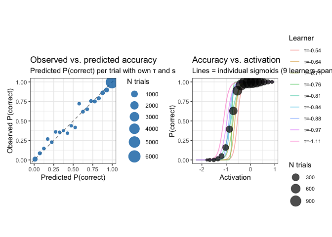

```r
# Recompute activation for each TEST trial, using ALL traces (including study trials)
sim_test <- sim[is_study == FALSE]

sim_test[, activation := mapply(function(uid, fid, t) {
  # Get all prior traces for this fact, INCLUDING the study trial
  traces <- sim[user_id == uid & fact_id == fid & start_time < t, start_time]
  if (length(traces) == 0) return(NA_real_)
  calculate_activation_memory(t, traces, sim[user_id == uid & fact_id == fid, true_total_sof[1]])
}, user_id, fact_id, start_time)]

sim_act <- sim_test[is.finite(activation)]

# Per-trial predicted P(correct) using that trial's own parameters
sim_act[, pred_correct := correct_likelihood(activation, true_tau, true_s)]

# Bin by predicted P(correct)
sim_act[, pred_bin := cut(pred_correct,
                          breaks = seq(0, 1, by = 0.05),
                          include.lowest = TRUE)]

calib <- sim_act[, .(
  obs_acc  = mean(correct),
  pred_acc = mean(pred_correct),
  n = .N
), by = pred_bin][n >= 5]

p_calib <- ggplot(calib, aes(x = pred_acc, y = obs_acc)) +
  geom_abline(slope = 1, intercept = 0, linetype = "dashed", color = "grey50") +
  geom_point(aes(size = n), color = "#0571b0", alpha = 0.8) +
  scale_size_continuous(range = c(1.5, 8), name = "N trials") +
  labs(title = "Observed vs. predicted accuracy",
       subtitle = "Predicted P(correct) per trial with own τ and s",
       x = "Predicted P(correct)", y = "Observed P(correct)") +
  coord_equal(xlim = c(0, 1), ylim = c(0, 1)) +
  theme_bw()

# Right panel: accuracy vs activation with individual sigmoids
sigmoid_learners <- sim_act[, .(true_tau = true_tau[1], true_s = true_s[1]), by = user_id]
sigmoid_learners <- sigmoid_learners[order(true_tau)][seq(1, .N, length.out = 9)]

act_seq <- seq(min(sim_act$activation), max(sim_act$activation), length.out = 200)
sigmoid_curves <- sigmoid_learners[, .(
  act = act_seq,
  pred = correct_likelihood(act_seq, true_tau, true_s)
), by = .(user_id, true_tau)]
sigmoid_curves[, label := sprintf("τ=%.2f", true_tau)]

# Bin by activation (equal-width)
act_range <- range(sim_act$activation)
sim_act[, act_bin := cut(activation,
                         breaks = seq(act_range[1], act_range[2], length.out = 21),
                         include.lowest = TRUE)]
act_binned <- sim_act[, .(
  obs_acc  = mean(correct),
  mean_act = mean(activation),
  n = .N
), by = act_bin][n >= 5]

p_sigmoid <- ggplot() +
  geom_line(data = sigmoid_curves, aes(x = act, y = pred, group = user_id, color = label),
            alpha = 0.5, linewidth = 0.6) +
  geom_point(data = act_binned, aes(x = mean_act, y = obs_acc, size = n),
             color = "black", alpha = 0.7) +
  scale_size_continuous(range = c(1.5, 8), name = "N trials") +
  scale_color_discrete(name = "Learner") +
  labs(title = "Accuracy vs. activation",
       subtitle = "Lines = individual sigmoids (9 learners spanning τ range)",
       x = "Activation", y = "P(correct)") +
  theme_bw() +
  theme(legend.text = element_text(size = 8))

p_calib + p_sigmoid
```

The left panel is a calibration plot: if the simulation is internally consistent, the binned points should fall close to the diagonal. The right panel shows how individual retrieval thresholds (τ) shift the sigmoid mapping from activation to response probability. The binned observed accuracies (black dots) should track the spread of individual curves.

## Check 3: Learning curves — accuracy and RT over repetitions

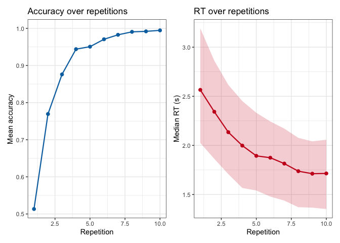

```r
sim_learn <- sim[is_study == FALSE]

learn_curve <- sim_learn[, .(
  accuracy = mean(correct),
  median_rt = median(rt),
  q25_rt = quantile(rt, 0.25),
  q75_rt = quantile(rt, 0.75)
), by = rep]

p_acc_rep <- ggplot(learn_curve, aes(x = rep, y = accuracy)) +
  geom_line(linewidth = 0.8, color = "#0571b0") +
  geom_point(size = 2, color = "#0571b0") +
  ylim(c(NA, 1)) +
  labs(title = "Accuracy over repetitions", x = "Repetition", y = "Mean accuracy") +
  theme_bw()

p_rt_rep <- ggplot(learn_curve, aes(x = rep, y = median_rt)) +
  geom_ribbon(aes(ymin = q25_rt, ymax = q75_rt), alpha = 0.2, fill = "#ca0020") +
  geom_line(linewidth = 0.8, color = "#ca0020") +
  geom_point(size = 2, color = "#ca0020") +
  labs(title = "RT over repetitions", x = "Repetition", y = "Median RT (s)") +
  theme_bw()

p_acc_rep + p_rt_rep
```

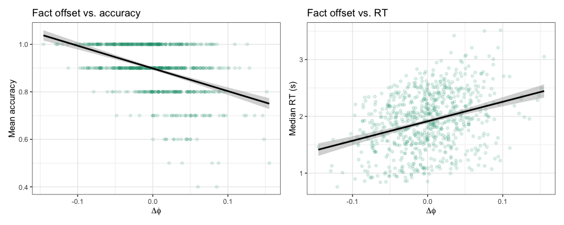

```r
fact_summary <- sim[is_study == FALSE, .(
  accuracy = mean(correct),
  median_rt = median(rt)
), by = .(user_id, fact_id, true_fact_offset)]

p_da_acc <- ggplot(fact_summary, aes(x = true_fact_offset, y = accuracy)) +
  geom_point(alpha = 0.15, color = "#1b9e77") +
  geom_smooth(method = "lm", color = "black", se = TRUE) +
  labs(title = "Fact offset vs. accuracy", x = expression(Delta*phi), y = "Mean accuracy") +
  theme_bw()

p_da_rt <- ggplot(fact_summary, aes(x = true_fact_offset, y = median_rt)) +
  geom_point(alpha = 0.15, color = "#1b9e77") +
  geom_smooth(method = "lm", color = "black", se = TRUE) +
  labs(title = "Fact offset vs. RT", x = expression(Delta*phi), y = "Median RT (s)") +
  theme_bw()

p_da_acc + p_da_rt
```

Higher fact offsets (Δφ) make a fact harder to retain, so accuracy should decrease and RT should increase with larger offsets. Each dot is one learner–fact combination.

## Check 5: Correct vs. incorrect RT distributions

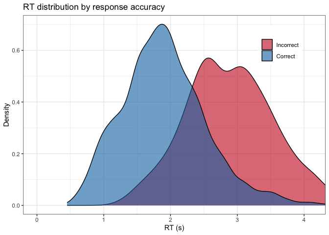

```r
sim_test <- sim[is_study == FALSE]

ggplot(sim_test, aes(x = rt, fill = correct)) +
  geom_density(alpha = 0.6) +
  scale_fill_manual(values = c("TRUE" = "#0571b0", "FALSE" = "#ca0020"),
                    labels = c("TRUE" = "Correct", "FALSE" = "Incorrect")) +
  labs(title = "RT distribution by response accuracy",
       x = "RT (s)", y = "Density", fill = "") +
  coord_cartesian(xlim = c(0, quantile(sim_test$rt, 0.99))) +
  theme_bw() +
  theme(legend.position = c(0.85, 0.85))
```

Correct responses should be faster than incorrect ones, consistent with the model’s assumption that higher activation produces both faster and more accurate retrieval. The distributions should overlap partially, with the incorrect-response distribution shifted towards longer RTs.